# Assignment 2: Spatial Analysis and Visualization

Healthcare Access and Equity in Pennsylvania

Author

Qianmu Zheng

Published

October 14, 2025

## Assignment Overview

**Learning Objectives:** - Apply spatial operations to answer policy-relevant research questions - Integrate census demographic data with spatial analysis - Create publication-quality visualizations and maps - Work with spatial data from multiple sources - Communicate findings effectively for policy audiences

## Part 1: Healthcare Access for Vulnerable Populations

### Research Question

**Which Pennsylvania counties have the highest proportion of vulnerable populations (elderly + low-income) living far from hospitals?**

#### Step 1: Data Collection (5 points)

```r
# Load required packages
library(sf)
library(tidyverse)
library(tigris)
library(tidycensus)
library(scales)
library(patchwork)
library(here)
# Load spatial data
data_path <- "D:/Desktop/musa/5080_policy/5080/MUSA-5080-Fall-2025/lectures/week-04/data"
census_api_key("940dffa67b928a0518accaf8839aa7b4762b11ab")

pa_counties <- st_read(file.path(data_path, "Pennsylvania_County_Boundaries.shp"))
hospitals <- st_read(file.path(data_path, "hospitals.geojson"))
census_tracts <- tracts(state = "PA", cb = TRUE)
# Check that all data loaded correctly
hospitals <- st_transform(hospitals, st_crs(pa_counties))
census_tracts <- st_transform(census_tracts, st_crs(pa_counties))

head(pa_counties)
```

```
Simple feature collection with 6 features and 19 fields
Geometry type: MULTIPOLYGON
Dimension:     XY
Bounding box:  xmin: -8905670 ymin: 4862594 xmax: -8317930 ymax: 5161279
Projected CRS: WGS 84 / Pseudo-Mercator
  OBJECTID MSLINK COUNTY_NAM COUNTY_NUM FIPS_COUNT COUNTY_ARE COUNTY_PER
1      336     46 MONTGOMERY         46        091       <NA>       <NA>
2      337      8   BRADFORD         08        015       <NA>       <NA>
3      338      9      BUCKS         09        017       <NA>       <NA>
4      339     58      TIOGA         58        117       <NA>       <NA>
5      340     59      UNION         59        119       <NA>       <NA>
6      341     60    VENANGO         60        121       <NA>       <NA>
  NUMERIC_LA COUNTY_N_1 AREA_SQ_MI SOUND SPREAD_SHE IMAGE_NAME NOTE_FILE VIDEO
1          5         46   487.4271  <NA>       <NA>   poll.bmp      <NA>  <NA>
2          2          8  1161.3379  <NA>       <NA>   poll.bmp      <NA>  <NA>
3          5          9   622.0836  <NA>       <NA>   poll.bmp      <NA>  <NA>
4          2         58  1137.2480  <NA>       <NA>   poll.bmp      <NA>  <NA>
5          2         59   319.1893  <NA>       <NA>   poll.bmp      <NA>  <NA>
6          3         60   683.3676  <NA>       <NA>   poll.bmp      <NA>  <NA>
  DISTRICT_N PA_CTY_COD MAINT_CTY_ DISTRICT_O                       geometry
1         06         46          4        6-4 MULTIPOLYGON (((-8398884 48...
2         03         08          9        3-9 MULTIPOLYGON (((-8558633 51...
3         06         09          1        6-1 MULTIPOLYGON (((-8367360 49...
4         03         59          7        3-7 MULTIPOLYGON (((-8558633 51...
5         03         60          8        3-8 MULTIPOLYGON (((-8562865 49...
6         01         61          5        1-5 MULTIPOLYGON (((-8870781 50...
```

```r
head(hospitals)
```

```
Simple feature collection with 6 features and 11 fields
Geometry type: POINT
Dimension:     XY
Bounding box:  xmin: -8936626 ymin: 4838244 xmax: -8367892 ymax: 4901278
Projected CRS: WGS 84 / Pseudo-Mercator
                 CHIEF_EXEC              CHIEF_EX_1
1             Peter J Adamo               President
2          Autumn DeShields Chief Executive Officer
3              Shawn Parekh Chief Executive Officer
4               DIANE HRITZ Chief Executive Officer
5            Tim Harclerode Chief Executive Officer
6 Richard McLaughlin MD MBA Chief Executive Officer
                      FACILITY_U LONGITUDE       COUNTY
1   https://www.phhealthcare.org -79.91131   Washington
2      https://www.malvernbh.com -75.17005 Philadelphia
```

[output cut: 18 more lines]

```r
head(census_tracts)
```

```
Simple feature collection with 6 features and 13 fields
Geometry type: MULTIPOLYGON
Dimension:     XY
Bounding box:  xmin: -8730207 ymin: 4835980 xmax: -8453342 ymax: 4945207
Projected CRS: WGS 84 / Pseudo-Mercator
  STATEFP COUNTYFP TRACTCE              GEOIDFQ       GEOID   NAME
1      42      001  031101 1400000US42001031101 42001031101 311.01
2      42      013  100400 1400000US42013100400 42013100400   1004
3      42      013  100500 1400000US42013100500 42013100500   1005
4      42      013  100800 1400000US42013100800 42013100800   1008
5      42      013  101900 1400000US42013101900 42013101900   1019
6      42      011  011200 1400000US42011011200 42011011200    112
             NAMELSAD STUSPS   NAMELSADCO   STATE_NAME LSAD   ALAND AWATER
1 Census Tract 311.01     PA Adams County Pennsylvania   CT 3043185      0
2   Census Tract 1004     PA Blair County Pennsylvania   CT  993724      0
3   Census Tract 1005     PA Blair County Pennsylvania   CT 1130204      0
4   Census Tract 1008     PA Blair County Pennsylvania   CT  996553      0
5   Census Tract 1019     PA Blair County Pennsylvania   CT  573726      0
6    Census Tract 112     PA Berks County Pennsylvania   CT 1539365   9308
                        geometry
1 MULTIPOLYGON (((-8575060 48...
2 MULTIPOLYGON (((-8730207 49...
3 MULTIPOLYGON (((-8729297 49...
4 MULTIPOLYGON (((-8728636 49...
5 MULTIPOLYGON (((-8728378 49...
6 MULTIPOLYGON (((-8455198 49...
```

```r
num_hospitals <- nrow(hospitals)
cat("Number of hospitals in dataset:", num_hospitals, "\n")
```

```
Number of hospitals in dataset: 223
```

```r
num_tracts <- nrow(census_tracts)
cat("Number of census tracts in dataset:", num_tracts, "\n")
```

```
Number of census tracts in dataset: 3445
```

```r
cat("\n---- Coordinate Reference Systems ----\n")
```

```
---- Coordinate Reference Systems ----
```

```r
cat("Counties CRS:\n"); print(st_crs(pa_counties))
```

```
Counties CRS:
```

[output not shown]

```r
cat("\nHospitals CRS:\n"); print(st_crs(hospitals))
```

```
Hospitals CRS:
```

[output not shown]

```r
cat("\nCensus Tracts CRS:\n"); print(st_crs(census_tracts))
```

```
Census Tracts CRS:
```

[output not shown]

#### Step 2: Get Demographic Data

Use `tidycensus` to download tract-level demographic data for Pennsylvania.

```r
# Get demographic data from ACS
library(tidycensus)
library(dplyr)
library(sf)

acs_year <- 2022

pa_basic <- get_acs(
  geography = "tract",
  state = "PA",
  variables = c(
    total_pop = "B01003_001",
    median_income = "B19013_001"
  ),
  year = acs_year,
  survey = "acs5",
  geometry = FALSE,
  output = "wide"
)

pa_age <- get_acs(
  geography = "tract",
  state = "PA",
  variables = c(
    male_65_66 = "B01001_020",
    male_67_69 = "B01001_021",
    male_70_74 = "B01001_022",
    male_75_79 = "B01001_023",
    male_80_84 = "B01001_024",
    male_85plus = "B01001_025",
    female_65_66 = "B01001_044",
    female_67_69 = "B01001_045",
    female_70_74 = "B01001_046",
    female_75_79 = "B01001_047",
    female_80_84 = "B01001_048",
    female_85plus = "B01001_049"
  ),
  year = acs_year,
  survey = "acs5",
  geometry = FALSE
)

pa_age_summary <- pa_age %>%
  group_by(GEOID) %>%
  summarize(pop_65_over = sum(estimate, na.rm = TRUE))

pa_demo <- pa_basic %>%
  left_join(pa_age_summary, by = "GEOID") %>%
  select(GEOID, total_popE, median_incomeE, pop_65_over) %>%
  rename(
    total_pop = total_popE,
    median_income = median_incomeE
  )

# Join to tract boundaries
census_tracts_demo <- census_tracts %>%
  left_join(pa_demo, by = c("GEOID" = "GEOID"))


# What year of ACS data?
cat("ACS Year Used:", acs_year, "\n")
```

```
ACS Year Used: 2022
```

```r
# How many tracts have missing income data?
missing_income <- sum(is.na(census_tracts_demo$median_income))
cat("Number of tracts with missing income data:", missing_income, "\n")
```

```
Number of tracts with missing income data: 62
```

```r
# What is the median income across all PA census tracts?
overall_median_income <- median(census_tracts_demo$median_income, na.rm = TRUE)
cat("Median income across all PA tracts:", dollar(overall_median_income), "\n")
```

```
Median income across all PA tracts: $70,188
```

#### Step 3: Define Vulnerable Populations

Identify census tracts with vulnerable populations based on TWO criteria: 1. Low median household income (choose an appropriate threshold) 2. Significant elderly population (choose an appropriate threshold)

```r
#### Step 3: Define Vulnerable Populations ----

income_threshold <- 50000
elderly_threshold <- 0.15

census_tracts_demo <- census_tracts_demo %>%
  mutate(
    pct_elderly =  pop_65_over/ total_pop
  )

vulnerable_tracts <- census_tracts_demo %>%
  filter(
    median_income < income_threshold &
    pct_elderly > elderly_threshold
  )

num_vulnerable <- nrow(vulnerable_tracts)
total_tracts <- nrow(census_tracts_demo)
pct_vulnerable <- (num_vulnerable / total_tracts) * 100

cat("Income threshold:", income_threshold, "\n")
```

```
Income threshold: 50000
```

```r
cat("Elderly population threshold:", elderly_threshold * 100, "%\n")
```

```
Elderly population threshold: 15 %
```

```r
cat("Number of vulnerable tracts:", num_vulnerable, "\n")
```

```
Number of vulnerable tracts: 312
```

```r
cat("Percentage of PA tracts considered vulnerable:", round(pct_vulnerable, 2), "%\n")
```

```
Percentage of PA tracts considered vulnerable: 9.06 %
```

#### Step 4: Calculate Distance to Hospitals

For each vulnerable tract, calculate the distance to the nearest hospital.

```r
library(units)
# Transform to appropriate projected CRS
projected_crs <- 26918

vulnerable_tracts_proj <- st_transform(vulnerable_tracts, crs = projected_crs)
hospitals_proj <- st_transform(hospitals, crs = projected_crs)

tract_centroids <- st_centroid(vulnerable_tracts_proj)

dist_matrix <- st_distance(tract_centroids, hospitals_proj)
nearest_hospital_dist_m <- apply(dist_matrix, 1, min)

nearest_hospital_dist_miles <- as.numeric(nearest_hospital_dist_m) / 1609.34

vulnerable_tracts_proj <- vulnerable_tracts_proj %>%
  mutate(distance_to_hospital_miles = nearest_hospital_dist_miles)

avg_distance <- mean(vulnerable_tracts_proj$distance_to_hospital_miles, na.rm = TRUE)
max_distance <- max(vulnerable_tracts_proj$distance_to_hospital_miles, na.rm = TRUE)
num_over_15 <- sum(vulnerable_tracts_proj$distance_to_hospital_miles > 15, na.rm = TRUE)

cat("Average distance to nearest hospital (miles):", round(avg_distance, 2), "\n")
```

```
Average distance to nearest hospital (miles): 3.17
```

```r
cat("Maximum distance to nearest hospital (miles):", round(max_distance, 2), "\n")
```

```
Maximum distance to nearest hospital (miles): 18.98
```

```r
cat("Number of vulnerable tracts >15 miles from hospital:", num_over_15, "\n")
```

```
Number of vulnerable tracts >15 miles from hospital: 9
```

#### Step 5: Identify Underserved Areas

Define “underserved” as vulnerable tracts that are more than 15 miles from the nearest hospital.

```r
# Create underserved variable

library(dplyr)

vulnerable_tracts_proj <- vulnerable_tracts_proj %>%
  mutate(
    underserved = distance_to_hospital_miles > 15
  )

num_underserved <- sum(vulnerable_tracts_proj$underserved, na.rm = TRUE)
total_vulnerable <- nrow(vulnerable_tracts_proj)
pct_underserved <- (num_underserved / total_vulnerable) * 100

cat("Number of underserved vulnerable tracts:", num_underserved, "\n")
```

```
Number of underserved vulnerable tracts: 9
```

```r
cat("Percentage of vulnerable tracts that are underserved:", round(pct_underserved, 2), "%\n")
```

```
Percentage of vulnerable tracts that are underserved: 2.88 %
```

#### Step 6: Aggregate to County Level

Use spatial joins and aggregation to calculate county-level statistics about vulnerable populations and hospital access.

```r
# Spatial join tracts to counties
#### Step 6: Aggregate to County Level ----

vulnerable_tracts_proj <- st_transform(vulnerable_tracts_proj, st_crs(pa_counties))

tracts_with_county <- st_join(vulnerable_tracts_proj, pa_counties, join = st_intersects, left = FALSE)

names(tracts_with_county)
```

```
 [1] "STATEFP"                    "COUNTYFP"
 [3] "TRACTCE"                    "GEOIDFQ"
 [5] "GEOID"                      "NAME"
 [7] "NAMELSAD"                   "STUSPS"
 [9] "NAMELSADCO"                 "STATE_NAME"
[11] "LSAD"                       "ALAND"
[13] "AWATER"                     "total_pop"
[15] "median_income"              "pop_65_over"
[17] "pct_elderly"                "distance_to_hospital_miles"
[19] "underserved"                "OBJECTID"
[21] "MSLINK"                     "COUNTY_NAM"
[23] "COUNTY_NUM"                 "FIPS_COUNT"
[25] "COUNTY_ARE"                 "COUNTY_PER"
[27] "NUMERIC_LA"                 "COUNTY_N_1"
[29] "AREA_SQ_MI"                 "SOUND"
[31] "SPREAD_SHE"                 "IMAGE_NAME"
[33] "NOTE_FILE"                  "VIDEO"
[35] "DISTRICT_N"                 "PA_CTY_COD"
[37] "MAINT_CTY_"                 "DISTRICT_O"
[39] "geometry"
```

```r
county_summary <- tracts_with_county %>%
  st_drop_geometry() %>%
  group_by(NAMELSADCO) %>%
  summarize(
    num_vulnerable_tracts = n(),
    num_underserved_tracts = sum(underserved, na.rm = TRUE),
    pct_underserved = (num_underserved_tracts / num_vulnerable_tracts) * 100,
    avg_distance_miles = mean(distance_to_hospital_miles, na.rm = TRUE),
    total_vulnerable_pop = sum(total_pop, na.rm = TRUE)
  ) %>%
  arrange(desc(pct_underserved))

head(county_summary)
```

```
# A tibble: 6 × 6
  NAMELSADCO        num_vulnerable_tracts num_underserved_tracts pct_underserved
  <chr>                             <int>                  <int>           <dbl>
1 Cameron County                        1                      1           100
2 Centre County                         2                      2           100
3 Forest County                         8                      8           100
4 Monroe County                         1                      1           100
5 Juniata County                        7                      5            71.4
6 Clearfield County                     6                      4            66.7
# ℹ 2 more variables: avg_distance_miles <dbl>, total_vulnerable_pop <dbl>
```

```r
# Aggregate statistics by county
```

```r
top5_underserved <- county_summary %>%
  arrange(desc(pct_underserved)) %>%
  slice(1:5)
print(top5_underserved)
```

```
# A tibble: 5 × 6
  NAMELSADCO     num_vulnerable_tracts num_underserved_tracts pct_underserved
  <chr>                          <int>                  <int>           <dbl>
1 Cameron County                     1                      1           100
2 Centre County                      2                      2           100
3 Forest County                      8                      8           100
4 Monroe County                      1                      1           100
5 Juniata County                     7                      5            71.4
# ℹ 2 more variables: avg_distance_miles <dbl>, total_vulnerable_pop <dbl>
```

```r
top_vuln_far <- county_summary %>%
  arrange(desc(total_vulnerable_pop)) %>%
  slice(1:5)
print(top_vuln_far)
```

```
# A tibble: 5 × 6
  NAMELSADCO        num_vulnerable_tracts num_underserved_tracts pct_underserved
  <chr>                             <int>                  <int>           <dbl>
1 Philadelphia Cou…                    57                      0               0
2 Allegheny County                     59                      0               0
3 Luzerne County                       18                      0               0
4 Westmoreland Cou…                    23                      0               0
5 Fayette County                       12                      0               0
# ℹ 2 more variables: avg_distance_miles <dbl>, total_vulnerable_pop <dbl>
```

#### Step 7: Create Summary Table

Create a professional table showing the top 10 priority counties for healthcare investment.

```r
# Create and format priority counties table
#### Step 7: Create Summary Table ----

library(knitr)
library(scales)

priority_metric <- "pct_underserved"

priority_counties <- county_summary %>%
  arrange(desc(!!sym(priority_metric))) %>%
  slice(1:10) %>%
  mutate(
    num_vulnerable_tracts = comma(num_vulnerable_tracts),
    num_underserved_tracts = comma(num_underserved_tracts),
    pct_underserved = percent(pct_underserved / 100, accuracy = 0.1),
    avg_distance_miles = round(avg_distance_miles, 1),
    total_vulnerable_pop = comma(total_vulnerable_pop)
  ) %>%
  rename(
    `County` = NAMELSADCO,
    `Vulnerable Tracts` = num_vulnerable_tracts,
    `Underserved Tracts` = num_underserved_tracts,
    `% Underserved` = pct_underserved,
    `Avg Distance (mi)` = avg_distance_miles,
    `Total Vulnerable Population` = total_vulnerable_pop
  )

kable(
  priority_counties,
  caption = "Table 1. Top 10 Pennsylvania Counties Prioritized for Healthcare Investment",
  align = "lccccc",
  format = "markdown"
)
```

Table 1. Top 10 Pennsylvania Counties Prioritized for Healthcare Investment

| County | Vulnerable Tracts | Underserved Tracts | % Underserved | Avg Distance (mi) | Total Vulnerable Population |
| --- | --- | --- | --- | --- | --- |
| Cameron County | 1 | 1 | 100.0% | 18.7 | 1,988 |
| Centre County | 2 | 2 | 100.0% | 15.2 | 6,654 |
| Forest County | 8 | 8 | 100.0% | 18.4 | 27,836 |
| Monroe County | 1 | 1 | 100.0% | 17.7 | 1,299 |
| Juniata County | 7 | 5 | 71.4% | 14.0 | 16,390 |
| Clearfield County | 6 | 4 | 66.7% | 15.9 | 17,238 |
| Adams County | 1 | 0 | 0.0% | 0.2 | 3,908 |
| Allegheny County | 59 | 0 | 0.0% | 2.1 | 146,496 |
| Armstrong County | 3 | 0 | 0.0% | 4.3 | 7,376 |
| Beaver County | 9 | 0 | 0.0% | 2.3 | 20,794 |

## Part 2: Comprehensive Visualization

Using the skills from Week 3 (Data Visualization), create publication-quality maps and charts.

### Map 1: County-Level Choropleth

Create a choropleth map showing healthcare access challenges at the county level.

```r
library(stringr)

county_summary <- county_summary %>%
  mutate(NAMELSADCO = str_replace(NAMELSADCO, " County$", ""))
```

```r
View(pa_counties)
View(county_summary)
```

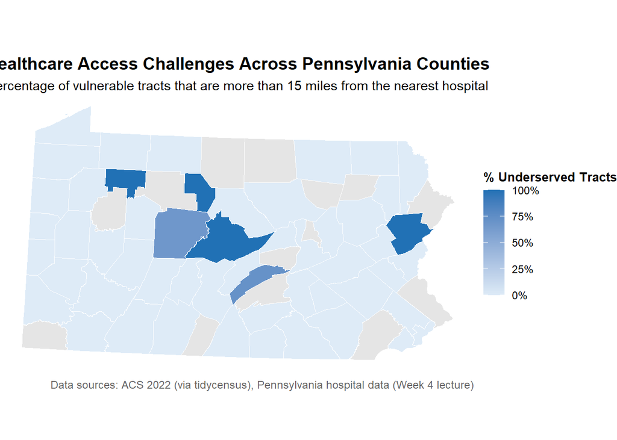

```r
# Create county-level access map
#### Part 2: County-Level Choropleth ----

library(ggplot2)
library(sf)
library(scales)

pa_counties_proj <- st_transform(pa_counties, 26918)
hospitals_proj <- st_transform(hospitals, 26918)


county_summary_map <- pa_counties_proj %>%
  mutate(COUNTY_NAM = tolower(COUNTY_NAM)) %>%
  left_join(
    county_summary %>%
      mutate(NAMELSADCO = tolower(NAMELSADCO)),
    by = c("COUNTY_NAM" = "NAMELSADCO")
  )


ggplot() +
  geom_sf(
    data = county_summary_map,
    aes(fill = pct_underserved),
    color = "white",
    size = 0.2
  ) +

  scale_fill_gradient(
    low = "#DEEBF7",
    high = "#2171B5",
    name = "% Underserved Tracts",
    labels = function(x) paste0(round(x, 0), "%"),
    na.value = "grey90"
  ) +

  labs(
    title = "Healthcare Access Challenges Across Pennsylvania Counties",
    subtitle = "Percentage of vulnerable tracts that are more than 15 miles from the nearest hospital",
    caption = "Data sources: ACS 2022 (via tidycensus), Pennsylvania hospital data (Week 4 lecture)"
  ) +

  theme_void(base_size = 12) +
  theme(
    plot.title = element_text(face = "bold", size = 14, hjust = 0.5),
    plot.subtitle = element_text(size = 11, hjust = 0.5),
    plot.caption = element_text(size = 9, hjust = 0.95, color = "gray40"),
    legend.position = "right",
    legend.title = element_text(size = 10, face = "bold"),
    legend.text = element_text(size = 9)
  )
```

### Map 2: Detailed Vulnerability Map

Create a map highlighting underserved vulnerable tracts.

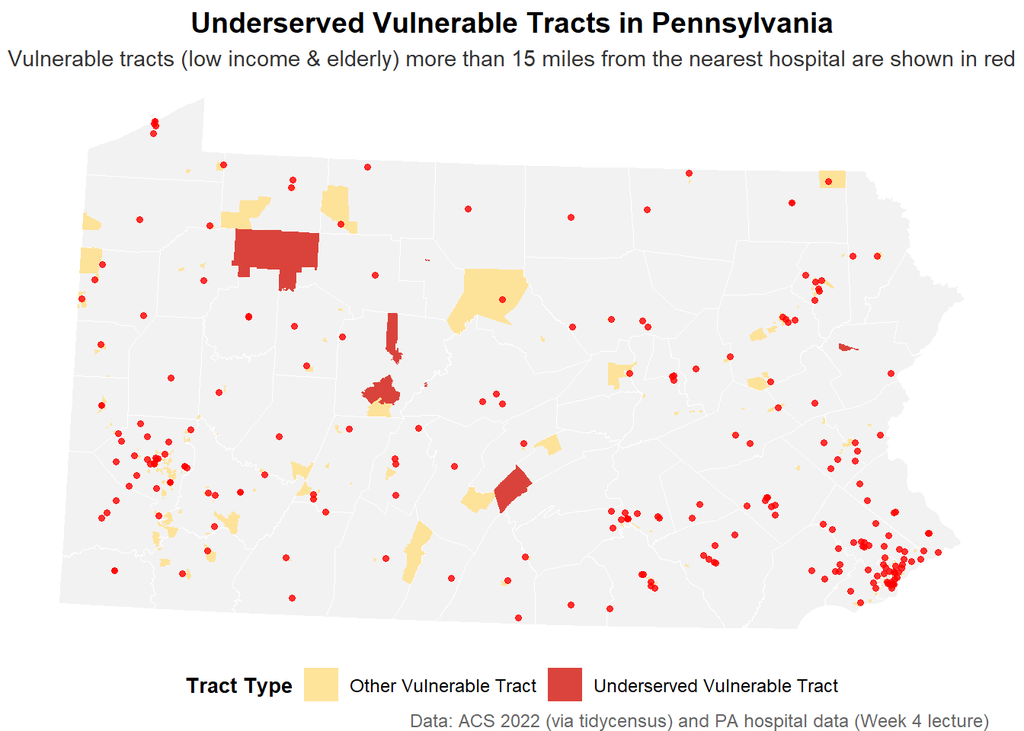

```r
# Create detailed tract-level map
#### Part 2: Map 2 - Detailed Vulnerability Map ----

pa_counties_proj <- st_transform(pa_counties, 26918)
hospitals_proj <- st_transform(hospitals, 26918)
vulnerable_tracts_proj <- st_transform(vulnerable_tracts_proj, 26918)

tract_map_data <- vulnerable_tracts_proj %>%
  mutate(
    tract_status = case_when(
      underserved ~ "Underserved Vulnerable Tract",
      TRUE ~ "Other Vulnerable Tract"
    )
  )

ggplot() +
  geom_sf(data = pa_counties_proj, fill = "gray95", color = "white", size = 0.3) +

  geom_sf(
    data = tract_map_data,
    aes(fill = tract_status),
    color = NA,
    alpha = 0.9
  ) +

  geom_sf(
    data = hospitals_proj,
    color = "red",
    size = 1.2,
    alpha = 0.8
  ) +

  scale_fill_manual(
    values = c(
      "Underserved Vulnerable Tract" = "#d73027",
      "Other Vulnerable Tract" = "#fee090"
    ),
    name = "Tract Type"
  ) +

  labs(
    title = "Underserved Vulnerable Tracts in Pennsylvania",
    subtitle = "Vulnerable tracts (low income & elderly) more than 15 miles from the nearest hospital are shown in red",
    caption = "Data: ACS 2022 (via tidycensus) and PA hospital data (Week 4 lecture)"
  ) +

  theme_void(base_size = 11) +
  theme(
    plot.title = element_text(face = "bold", size = 14, hjust = 0.5),
    plot.subtitle = element_text(size = 11, hjust = 0.5, color = "gray20"),
    plot.caption = element_text(size = 9, color = "gray40", hjust = 0.95),
    legend.position = "bottom",
    legend.title = element_text(face = "bold", size = 10),
    legend.text = element_text(size = 9)
  )
```

### Chart: Distribution Analysis

Create a visualization showing the distribution of distances to hospitals for vulnerable populations.

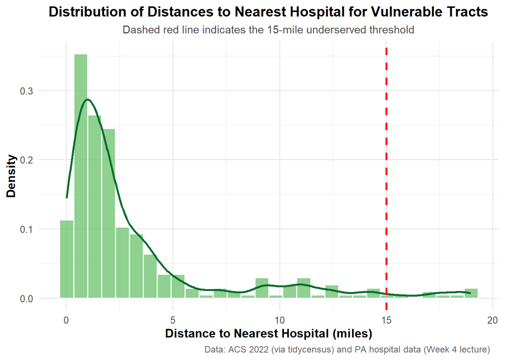

```r
# Create distribution visualization
#### Chart: Distribution Analysis ----

library(ggplot2)
library(scales)

ggplot(vulnerable_tracts_proj, aes(x = distance_to_hospital_miles)) +
  geom_histogram(
    aes(y = after_stat(density)),
    bins = 30,
    fill = "#74c476",
    color = "white",
    alpha = 0.8
  ) +
  geom_density(color = "#006d2c", linewidth = 1) +
  geom_vline(xintercept = 15, linetype = "dashed", color = "red", linewidth = 1) +
  labs(
    title = "Distribution of Distances to Nearest Hospital for Vulnerable Tracts",
    subtitle = "Dashed red line indicates the 15-mile underserved threshold",
    x = "Distance to Nearest Hospital (miles)",
    y = "Density",
    caption = "Data: ACS 2022 (via tidycensus) and PA hospital data (Week 4 lecture)"
  ) +
  theme_minimal(base_size = 12) +
  theme(
    plot.title = element_text(face = "bold", hjust = 0.5, size = 14),
    plot.subtitle = element_text(size = 11, hjust = 0.5, color = "gray30"),
    plot.caption = element_text(size = 9, color = "gray40", hjust = 0.95),
    axis.title = element_text(face = "bold")
  )
```

## Part 3: Bring Your Own Data Analysis

Choose your own additional spatial dataset and conduct a supplementary analysis.

1. **Find and load additional data**
   - Document your data source
   - Check and standardize the CRS
   - Provide basic summary statistics

```r
# Load your additional dataset
base_path = "D:\\Desktop\\musa\\5080_policy\\portfolio-setup-xqdqc-hub\\assignments\\assignment_2\\data"

schools <- st_read(file.path(base_path, "Schools\\Schools.shp"))
crime <- st_read(file.path(base_path,"incidents_part1_part2\\incidents_part1_part2.shp"))
```

```
replacing null geometries with empty geometries
Simple feature collection with 160388 features and 13 fields (with 6744 geometries empty)
Geometry type: POINT
Dimension:     XY
Bounding box:  xmin: -80.50237 ymin: 39.87688 xmax: -74.95784 ymax: 42.22434
Geodetic CRS:  WGS 84
```

```r
bike_net <- st_read(file.path(base_path,"Bike_Network\\Bike_Network.shp"))
```

```r
cat("Schools CRS:\n"); print(st_crs(schools))
```

```
Schools CRS:
```

[output not shown]

```r
cat("\nCrime Incidents CRS:\n"); print(st_crs(crime))
```

```
Crime Incidents CRS:
```

```
Coordinate Reference System:
  User input: WGS 84
  wkt:
GEOGCRS["WGS 84",
    DATUM["World Geodetic System 1984",
        ELLIPSOID["WGS 84",6378137,298.257223563,
            LENGTHUNIT["metre",1]]],
    PRIMEM["Greenwich",0,
        ANGLEUNIT["degree",0.0174532925199433]],
    CS[ellipsoidal,2],
        AXIS["latitude",north,
            ORDER[1],
            ANGLEUNIT["degree",0.0174532925199433]],
        AXIS["longitude",east,
            ORDER[2],
            ANGLEUNIT["degree",0.0174532925199433]],
    ID["EPSG",4326]]
```

```r
cat("\nBike Network CRS:\n"); print(st_crs(bike_net))
```

```
Bike Network CRS:
```

[output not shown]

```r
crime <- st_transform(crime, 3857)
```

```r
cat("\nSchools:\n")
```

```
Schools:
```

```r
cat("Number of schools:", nrow(schools), "\n")
```

```
Number of schools: 495
```

```r
print(st_geometry_type(schools) %>% table())
```

```
.
          GEOMETRY              POINT         LINESTRING            POLYGON
                 0                495                  0                  0
        MULTIPOINT    MULTILINESTRING       MULTIPOLYGON GEOMETRYCOLLECTION
                 0                  0                  0                  0
    CIRCULARSTRING      COMPOUNDCURVE       CURVEPOLYGON         MULTICURVE
                 0                  0                  0                  0
      MULTISURFACE              CURVE            SURFACE  POLYHEDRALSURFACE
                 0                  0                  0                  0
               TIN           TRIANGLE
                 0                  0
```

```r
print(summary(st_bbox(schools)))
```

```
    Min.  1st Qu.   Median     Mean  3rd Qu.     Max.
-8378628 -8353921 -1746565 -1746736  4860620  4884814
```

```r
cat("\nCrime Incidents:\n")
```

```
Crime Incidents:
```

```r
cat("Number of records:", nrow(crime), "\n")
```

```
Number of records: 160388
```

```r
print(st_geometry_type(crime) %>% table())
```

```
.
          GEOMETRY              POINT         LINESTRING            POLYGON
                 0             160388                  0                  0
        MULTIPOINT    MULTILINESTRING       MULTIPOLYGON GEOMETRYCOLLECTION
                 0                  0                  0                  0
    CIRCULARSTRING      COMPOUNDCURVE       CURVEPOLYGON         MULTICURVE
                 0                  0                  0                  0
      MULTISURFACE              CURVE            SURFACE  POLYHEDRALSURFACE
                 0                  0                  0                  0
               TIN           TRIANGLE
                 0                  0
```

```r
print(summary(st_bbox(crime)))
```

```
    Min.  1st Qu.   Median     Mean  3rd Qu.     Max.
-8961483 -8498572 -1748101 -1815760  4934711  5194643
```

```r
cat("\nBike Network:\n")
```

```
Bike Network:
```

```r
cat("Number of segments:", nrow(bike_net), "\n")
```

```
Number of segments: 5225
```

```r
print(st_geometry_type(bike_net) %>% table())
```

```
.
          GEOMETRY              POINT         LINESTRING            POLYGON
                 0                  0               5225                  0
        MULTIPOINT    MULTILINESTRING       MULTIPOLYGON GEOMETRYCOLLECTION
                 0                  0                  0                  0
    CIRCULARSTRING      COMPOUNDCURVE       CURVEPOLYGON         MULTICURVE
                 0                  0                  0                  0
      MULTISURFACE              CURVE            SURFACE  POLYHEDRALSURFACE
                 0                  0                  0                  0
               TIN           TRIANGLE
                 0                  0
```

```r
print(summary(st_bbox(bike_net)))
```

```
    Min.  1st Qu.   Median     Mean  3rd Qu.     Max.
-8378937 -8353594 -1748656 -1748068  4856871  4883978
```

**Questions to answer:** - What dataset did you choose and why?

I have chosen School dataset because I’m interested in young children issue.

- What is the data source and date?

Crime Incidents is in 2024, and I also have school dataset and bike network dataset.

- How many features does it contain?

Number of schools is 495, number of crime records is 160388, number of bike network segments is 5225.

- What CRS is it in? Did you need to transform it?

The CRS of schools and bike network data is EPSG 3857, the CRS of crime data is EPSG 4326. So I have got crime data transformed.

2. **Pose a research question**

Write a clear research statement that your analysis will answer.

This analysis investigates whether school zones in Philadelphia are safe environments, by examining the number of nearby crime incidents.

3. **Conduct spatial analysis**

```r
# Your spatial analysis
school_buffers <- st_buffer(schools, dist = 1000)

crime_join <- st_join(crime, school_buffers, join = st_within, left = FALSE)
```

```r
View(crime_join)
```

```r
school_crime_count <- crime_join %>%
  st_drop_geometry() %>%
  group_by(school_nam) %>%
  summarize(crime_count = n())

schools_with_crime <- schools %>%
  left_join(school_crime_count, by = "school_nam") %>%
  mutate(crime_count = replace_na(crime_count, 0))
```

```r
head(schools_with_crime)
```

```
Simple feature collection with 6 features and 15 fields
Geometry type: POINT
Dimension:     XY
Bounding box:  xmin: -8366653 ymin: 4857549 xmax: -8346614 ymax: 4878677
Projected CRS: WGS 84 / Pseudo-Mercator
        aun school_num location_i                     school_nam
1 226518902         NA       <NA> ST MARYS INTERPAROCHIAL SCHOOL
2 226518722         NA       <NA>               ST MARTHA SCHOOL
3 226514052         NA       <NA>           MATERNITY BVM SCHOOL
4 226514852         NA       <NA>     OUR LADY OF CALVARY SCHOOL
5 226511102         NA       <NA>         CHRIST THE KING SCHOOL
6 300511820         NA       <NA>     BEGINNINGS LEARNING CENTER
                      school_n_1             street_add zip_code     phone_numb
1 ST MARYS INTERPAROCHIAL SCHOOL          440 LOCUST ST    19106 (215) 923-7522
2               ST MARTHA SCHOOL       11321 ACADEMY RD    19154 (215) 632-0320
```

[output cut: 18 more lines]

```r
bike_in_buffers <- st_intersection(bike_net, school_buffers)

bike_coverage <- bike_in_buffers %>%
  st_drop_geometry() %>%
  group_by(school_nam) %>%
  summarize(bike_miles = sum(st_length(bike_in_buffers) / 5280))

schools_with_bike <- schools_with_crime %>%
  left_join(bike_coverage, by = c("school_nam")) %>%
  mutate(bike_miles = replace_na(bike_miles))

head(schools_with_bike)
```

```
Simple feature collection with 6 features and 16 fields
Geometry type: POINT
Dimension:     XY
Bounding box:  xmin: -8366653 ymin: 4857549 xmax: -8346614 ymax: 4878677
Projected CRS: WGS 84 / Pseudo-Mercator
        aun school_num location_i                     school_nam
1 226518902         NA       <NA> ST MARYS INTERPAROCHIAL SCHOOL
2 226518722         NA       <NA>               ST MARTHA SCHOOL
3 226514052         NA       <NA>           MATERNITY BVM SCHOOL
4 226514852         NA       <NA>     OUR LADY OF CALVARY SCHOOL
5 226511102         NA       <NA>         CHRIST THE KING SCHOOL
6 300511820         NA       <NA>     BEGINNINGS LEARNING CENTER
                      school_n_1             street_add zip_code     phone_numb
1 ST MARYS INTERPAROCHIAL SCHOOL          440 LOCUST ST    19106 (215) 923-7522
2               ST MARTHA SCHOOL       11321 ACADEMY RD    19154 (215) 632-0320
```

[output cut: 18 more lines]

```r
summary_tbl <- schools_with_bike %>%
  st_drop_geometry() %>%
  summarize(
    total_schools = n(),
    avg_crime = mean(crime_count, na.rm = TRUE),
    avg_bike = mean(bike_miles, na.rm = TRUE)
  )

print(summary_tbl)
```

```
  total_schools avg_crime     avg_bike
1           495  1460.842 484.4795 [m]
```

[figure not shown]

```r
ggplot(data = schools_with_crime) +
  geom_sf(aes(color = crime_count), size = 2) +
  scale_color_viridis_c(
    option = "plasma",
    trans = "sqrt",
    name = "Crime Count"
  ) +
  labs(
    title = "Crime Incidents Within 1000ft of Philadelphia Schools",
    subtitle = "Each point represents a school, colored by number of nearby crime incidents",
    caption = "Data: OpenDataPhilly | Analysis: MUSA 5080 Assignment 3"
  ) +
  theme_minimal(base_size = 12) +
  theme(
    plot.title = element_text(face = "bold", size = 14, hjust = 0.5),
    plot.subtitle = element_text(size = 10, hjust = 0.5, color = "gray30"),
    legend.position = "right"
  )
```

[figure not shown]

```r
ggplot(schools_with_crime, aes(x = crime_count)) +
  geom_histogram(
    bins = 30,
    fill = "pink",
    color = "white",
    alpha = 0.8
  ) +
  labs(
    title = "Distribution of Crime Incidents Within 1000ft of Schools",
    subtitle = "Each bar represents the number of schools by nearby crime count",
    x = "Number of Crime Incidents (within 1000ft)",
    y = "Number of Schools",
    caption = "Data: OpenDataPhilly | Analysis: MUSA 5080 Assignment 3"
  ) +
  theme_minimal(base_size = 12) +
  theme(
    plot.title = element_text(face = "bold", size = 14, hjust = 0.5),
    plot.subtitle = element_text(size = 10, hjust = 0.5, color = "gray30"),
    plot.caption = element_text(size = 8, color = "gray50", hjust = 0.95)
  )
```